# Optimal Treatment Analysis

## Outcome Variable

**Outcome Variable:** whz

## Predictor Variables

**Intervention Variable:** perdiar24

**Adjustment Set:**

- arm
- sex
- W_mage
- meducyrs
- hfoodsec
- W_mhtcm
- W_mwtkg
- W_mbmi
- W_birthwt
- W_birthlen
- W_nrooms
- month
- brthmon
- impfloor
- impsan
- safeh20
- delta_W_mage
- delta_meducyrs
- delta_hfoodsec
- delta_W_mhtcm
- delta_W_mwtkg
- delta_W_mbmi
- delta_W_birthwt
- delta_W_birthlen
- delta_W_nrooms
- delta_month
- delta_brthmon
- delta_impfloor
- delta_impsan
- delta_safeh20

## Stratifying Variables

The analysis was stratified on these variable(s):

- agecat
- studyid
- country

## Data Summary

| agecat | studyid | country | perdiar24 | n_cell | n |
| --- | --- | --- | --- | --- | --- |
| Birth | ki0047075b-MAL-ED | BANGLADESH | (0%, 5%] | 142 | 241 |
| Birth | ki0047075b-MAL-ED | BANGLADESH | >5% | 81 | 241 |
| Birth | ki0047075b-MAL-ED | BANGLADESH | 0% | 18 | 241 |
| Birth | ki0047075b-MAL-ED | BRAZIL | (0%, 5%] | 76 | 183 |
| Birth | ki0047075b-MAL-ED | BRAZIL | >5% | 2 | 183 |
| Birth | ki0047075b-MAL-ED | BRAZIL | 0% | 105 | 183 |
| Birth | ki0047075b-MAL-ED | INDIA | (0%, 5%] | 153 | 203 |
| Birth | ki0047075b-MAL-ED | INDIA | >5% | 38 | 203 |
| Birth | ki0047075b-MAL-ED | INDIA | 0% | 12 | 203 |
| Birth | ki0047075b-MAL-ED | NEPAL | (0%, 5%] | 101 | 168 |
| Birth | ki0047075b-MAL-ED | NEPAL | >5% | 54 | 168 |
| Birth | ki0047075b-MAL-ED | NEPAL | 0% | 13 | 168 |
| Birth | ki0047075b-MAL-ED | PERU | (0%, 5%] | 107 | 279 |
| Birth | ki0047075b-MAL-ED | PERU | >5% | 146 | 279 |
| Birth | ki0047075b-MAL-ED | PERU | 0% | 26 | 279 |
| Birth | ki0047075b-MAL-ED | SOUTH AFRICA | (0%, 5%] | 152 | 250 |
| Birth | ki0047075b-MAL-ED | SOUTH AFRICA | >5% | 3 | 250 |
| Birth | ki0047075b-MAL-ED | SOUTH AFRICA | 0% | 95 | 250 |
| Birth | ki0047075b-MAL-ED | TANZANIA, UNITED REPUBLIC OF | (0%, 5%] | 86 | 118 |
| Birth | ki0047075b-MAL-ED | TANZANIA, UNITED REPUBLIC OF | >5% | 24 | 118 |
| Birth | ki0047075b-MAL-ED | TANZANIA, UNITED REPUBLIC OF | 0% | 8 | 118 |
| Birth | ki1000109-EE | PAKISTAN | (0%, 5%] | 1 | 1 |
| Birth | ki1000109-EE | PAKISTAN | >5% | 0 | 1 |
| Birth | ki1000109-EE | PAKISTAN | 0% | 0 | 1 |
| Birth | ki1000109-ResPak | PAKISTAN | (0%, 5%] | 1 | 5 |
| Birth | ki1000109-ResPak | PAKISTAN | >5% | 4 | 5 |
| Birth | ki1000109-ResPak | PAKISTAN | 0% | 0 | 5 |
| Birth | ki1017093-NIH-Birth | BANGLADESH | (0%, 5%] | 8 | 26 |
| Birth | ki1017093-NIH-Birth | BANGLADESH | >5% | 14 | 26 |
| Birth | ki1017093-NIH-Birth | BANGLADESH | 0% | 4 | 26 |

[output cut: 123 more lines]

The following strata were considered:

- agecat: 24 months, studyid: ki0047075b-MAL-ED, country: BANGLADESH
- agecat: 24 months, studyid: ki0047075b-MAL-ED, country: BRAZIL
- agecat: 24 months, studyid: ki0047075b-MAL-ED, country: INDIA
- agecat: 24 months, studyid: ki0047075b-MAL-ED, country: NEPAL
- agecat: 24 months, studyid: ki0047075b-MAL-ED, country: PERU
- agecat: 24 months, studyid: ki0047075b-MAL-ED, country: SOUTH AFRICA
- agecat: 24 months, studyid: ki0047075b-MAL-ED, country: TANZANIA, UNITED REPUBLIC OF
- agecat: 24 months, studyid: ki1017093-NIH-Birth, country: BANGLADESH
- agecat: 24 months, studyid: ki1017093b-PROVIDE, country: BANGLADESH
- agecat: 24 months, studyid: ki1017093c-NIH-Crypto, country: BANGLADESH
- agecat: 24 months, studyid: ki1114097-CMIN, country: BANGLADESH
- agecat: 24 months, studyid: ki1114097-CMIN, country: GUINEA-BISSAU
- agecat: 24 months, studyid: ki1114097-CMIN, country: PERU
- agecat: 24 months, studyid: ki1114097-CONTENT, country: PERU
- agecat: 24 months, studyid: kiGH5241-JiVitA-4, country: BANGLADESH
- agecat: 6 months, studyid: ki0047075b-MAL-ED, country: BANGLADESH
- agecat: 6 months, studyid: ki0047075b-MAL-ED, country: BRAZIL
- agecat: 6 months, studyid: ki0047075b-MAL-ED, country: INDIA
- agecat: 6 months, studyid: ki0047075b-MAL-ED, country: NEPAL
- agecat: 6 months, studyid: ki0047075b-MAL-ED, country: PERU
- agecat: 6 months, studyid: ki0047075b-MAL-ED, country: SOUTH AFRICA
- agecat: 6 months, studyid: ki0047075b-MAL-ED, country: TANZANIA, UNITED REPUBLIC OF
- agecat: 6 months, studyid: ki1000109-EE, country: PAKISTAN
- agecat: 6 months, studyid: ki1000109-ResPak, country: PAKISTAN
- agecat: 6 months, studyid: ki1000304b-SAS-FoodSuppl, country: INDIA
- agecat: 6 months, studyid: ki1017093-NIH-Birth, country: BANGLADESH
- agecat: 6 months, studyid: ki1017093b-PROVIDE, country: BANGLADESH
- agecat: 6 months, studyid: ki1017093c-NIH-Crypto, country: BANGLADESH
- agecat: 6 months, studyid: ki1112895-Guatemala BSC, country: GUATEMALA
- agecat: 6 months, studyid: ki1114097-CMIN, country: BANGLADESH
- agecat: 6 months, studyid: ki1114097-CMIN, country: BRAZIL
- agecat: 6 months, studyid: ki1114097-CMIN, country: GUINEA-BISSAU
- agecat: 6 months, studyid: ki1114097-CMIN, country: PERU
- agecat: 6 months, studyid: ki1114097-CONTENT, country: PERU
- agecat: 6 months, studyid: kiGH5241-JiVitA-4, country: BANGLADESH
- agecat: Birth, studyid: ki0047075b-MAL-ED, country: BANGLADESH
- agecat: Birth, studyid: ki0047075b-MAL-ED, country: BRAZIL
- agecat: Birth, studyid: ki0047075b-MAL-ED, country: INDIA
- agecat: Birth, studyid: ki0047075b-MAL-ED, country: NEPAL
- agecat: Birth, studyid: ki0047075b-MAL-ED, country: PERU
- agecat: Birth, studyid: ki0047075b-MAL-ED, country: SOUTH AFRICA
- agecat: Birth, studyid: ki0047075b-MAL-ED, country: TANZANIA, UNITED REPUBLIC OF
- agecat: Birth, studyid: ki1000109-EE, country: PAKISTAN
- agecat: Birth, studyid: ki1000109-ResPak, country: PAKISTAN
- agecat: Birth, studyid: ki1017093-NIH-Birth, country: BANGLADESH
- agecat: Birth, studyid: ki1017093c-NIH-Crypto, country: BANGLADESH
- agecat: Birth, studyid: ki1114097-CMIN, country: BANGLADESH
- agecat: Birth, studyid: ki1114097-CMIN, country: BRAZIL
- agecat: Birth, studyid: ki1114097-CMIN, country: PERU
- agecat: Birth, studyid: ki1114097-CONTENT, country: PERU
- agecat: Birth, studyid: kiGH5241-JiVitA-4, country: BANGLADESH

### Dropped Strata

Some strata were dropped due to rare outcomes:

- agecat: Birth, studyid: ki0047075b-MAL-ED, country: BRAZIL
- agecat: Birth, studyid: ki0047075b-MAL-ED, country: SOUTH AFRICA
- agecat: Birth, studyid: ki1000109-EE, country: PAKISTAN
- agecat: Birth, studyid: ki1000109-ResPak, country: PAKISTAN
- agecat: Birth, studyid: ki1017093-NIH-Birth, country: BANGLADESH
- agecat: Birth, studyid: ki1017093c-NIH-Crypto, country: BANGLADESH
- agecat: Birth, studyid: ki1114097-CMIN, country: BANGLADESH
- agecat: Birth, studyid: ki1114097-CMIN, country: BRAZIL
- agecat: Birth, studyid: ki1114097-CMIN, country: PERU
- agecat: Birth, studyid: ki1114097-CONTENT, country: PERU
- agecat: 6 months, studyid: ki0047075b-MAL-ED, country: BRAZIL
- agecat: 6 months, studyid: ki0047075b-MAL-ED, country: INDIA
- agecat: 6 months, studyid: ki0047075b-MAL-ED, country: SOUTH AFRICA
- agecat: 6 months, studyid: ki1000304b-SAS-FoodSuppl, country: INDIA
- agecat: 6 months, studyid: ki1114097-CMIN, country: BANGLADESH
- agecat: 6 months, studyid: ki1114097-CMIN, country: BRAZIL
- agecat: 24 months, studyid: ki0047075b-MAL-ED, country: BRAZIL
- agecat: 24 months, studyid: ki0047075b-MAL-ED, country: INDIA
- agecat: 24 months, studyid: ki0047075b-MAL-ED, country: PERU
- agecat: 24 months, studyid: ki0047075b-MAL-ED, country: SOUTH AFRICA
- agecat: 24 months, studyid: ki1114097-CMIN, country: BANGLADESH
- agecat: 24 months, studyid: ki1114097-CONTENT, country: PERU

## Methods Detail

We’re interested in the causal parameters $E[Y_a]$ for all values of $a \in \mathcal{A}$. These parameters represent the mean outcome if, possibly contrary to fact, we intervened to set all units to have $A=a$. Under the randomization and positivity assumptions, these are identified by the statistical parameters $\psi_a=E_W[E_{Y|A,W}(Y|A=a,W)]$. In addition, we’re interested in the mean of $Y$, $E[Y]$ under no intervention (the observed mean). We will estimate these parameters by using SuperLearner to fit the relevant likelihood factors – $E_{Y|A,W}(Y|A=a,W)$ and $p(A=a|W)$, and then updating our likelihood fit using a joint TMLE.

For unadjusted analyses ($W=\{\}$), initial likelihoods were estimated using Lrnr_glm to estimate the simple $E(Y|A)$ and Lrnr_mean to estimate $p(A)$. For adjusted analyses, a small library containing Lrnr_glmnet, Lrnr_xgboost, and Lrnr_mean was used.

Having estimated these parameters, we will then use the delta method to estimate relative risks and attributable risks relative to a prespecified baseline level of $A$.

# Results Detail

## Results Plots

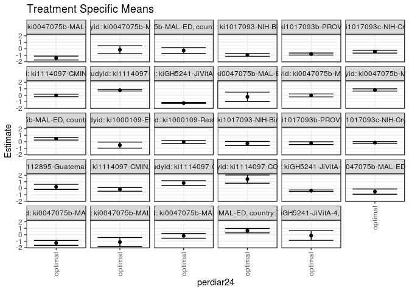

## Results Table

### Parameter: TSM

| agecat | studyid | country | intervention_level | baseline_level | estimate | ci_lower | ci_upper |
| --- | --- | --- | --- | --- | --- | --- | --- |
| Birth | ki0047075b-MAL-ED | BANGLADESH | optimal | observed | -0.5170672 | -0.9195549 | -0.1145795 |
| Birth | ki0047075b-MAL-ED | INDIA | optimal | observed | -1.2589010 | -1.6381228 | -0.8796793 |
| Birth | ki0047075b-MAL-ED | NEPAL | optimal | observed | -1.1322720 | -1.8307688 | -0.4337752 |
| Birth | ki0047075b-MAL-ED | PERU | optimal | observed | -0.1652341 | -0.5373921 | 0.2069239 |
| Birth | ki0047075b-MAL-ED | TANZANIA, UNITED REPUBLIC OF | optimal | observed | 0.6269500 | 0.2853104 | 0.9685897 |
| Birth | kiGH5241-JiVitA-4 | BANGLADESH | optimal | observed | -0.1250824 | -0.8667153 | 0.6165505 |
| 6 months | ki0047075b-MAL-ED | BANGLADESH | optimal | observed | -0.2374714 | -0.9566131 | 0.4816703 |
| 6 months | ki0047075b-MAL-ED | NEPAL | optimal | observed | -0.0283747 | -0.2581154 | 0.2013660 |
| 6 months | ki0047075b-MAL-ED | PERU | optimal | observed | 0.8168769 | 0.6448420 | 0.9889118 |
| 6 months | ki0047075b-MAL-ED | TANZANIA, UNITED REPUBLIC OF | optimal | observed | 0.4607804 | 0.2632764 | 0.6582844 |
| 6 months | ki1000109-EE | PAKISTAN | optimal | observed | -0.5175361 | -0.9825751 | -0.0524971 |
| 6 months | ki1000109-ResPak | PAKISTAN | optimal | observed | -0.0422854 | -0.2634919 | 0.1789210 |
| 6 months | ki1017093-NIH-Birth | BANGLADESH | optimal | observed | -0.2646825 | -0.5848816 | 0.0555167 |
| 6 months | ki1017093b-PROVIDE | BANGLADESH | optimal | observed | -0.2224249 | -0.4338827 | -0.0109671 |
| 6 months | ki1017093c-NIH-Crypto | BANGLADESH | optimal | observed | -0.1408576 | -0.2947898 | 0.0130747 |
| 6 months | ki1112895-Guatemala BSC | GUATEMALA | optimal | observed | 0.2136845 | -0.1797127 | 0.6070818 |
| 6 months | ki1114097-CMIN | GUINEA-BISSAU | optimal | observed | -0.1692978 | -0.4540631 | 0.1154676 |
| 6 months | ki1114097-CMIN | PERU | optimal | observed | 0.8006043 | 0.4390474 | 1.1621612 |
| 6 months | ki1114097-CONTENT | PERU | optimal | observed | 1.4094411 | 0.7770593 | 2.0418230 |
| 6 months | kiGH5241-JiVitA-4 | BANGLADESH | optimal | observed | -0.3828508 | -0.4975982 | -0.2681035 |
| 24 months | ki0047075b-MAL-ED | BANGLADESH | optimal | observed | -1.4275647 | -1.7291160 | -1.1260134 |
| 24 months | ki0047075b-MAL-ED | NEPAL | optimal | observed | -0.1574297 | -0.7696054 | 0.4547460 |
| 24 months | ki0047075b-MAL-ED | TANZANIA, UNITED REPUBLIC OF | optimal | observed | -0.2792560 | -0.7201707 | 0.1616588 |
| 24 months | ki1017093-NIH-Birth | BANGLADESH | optimal | observed | -0.9548886 | -1.1572856 | -0.7524915 |
| 24 months | ki1017093b-PROVIDE | BANGLADESH | optimal | observed | -0.8155445 | -0.9716566 | -0.6594325 |
| 24 months | ki1017093c-NIH-Crypto | BANGLADESH | optimal | observed | -0.4469062 | -0.6682093 | -0.2256030 |
| 24 months | ki1114097-CMIN | GUINEA-BISSAU | optimal | observed | -0.0264814 | -0.2266669 | 0.1737042 |
| 24 months | ki1114097-CMIN | PERU | optimal | observed | 0.7776732 | 0.6581772 | 0.8971693 |
| 24 months | kiGH5241-JiVitA-4 | BANGLADESH | optimal | observed | -1.2055337 | -1.2725938 | -1.1384737 |

### Parameter: E(Y)

| agecat | studyid | country | intervention_level | baseline_level | estimate | ci_lower | ci_upper |
| --- | --- | --- | --- | --- | --- | --- | --- |
| Birth | ki0047075b-MAL-ED | BANGLADESH | observed | observed | -0.9630705 | -1.0989132 | -0.8272278 |
| Birth | ki0047075b-MAL-ED | INDIA | observed | observed | -1.0691133 | -1.2078629 | -0.9303637 |
| Birth | ki0047075b-MAL-ED | NEPAL | observed | observed | -0.9044643 | -1.0439568 | -0.7649718 |
| Birth | ki0047075b-MAL-ED | PERU | observed | observed | -0.0735842 | -0.1836203 | 0.0364518 |
| Birth | ki0047075b-MAL-ED | TANZANIA, UNITED REPUBLIC OF | observed | observed | 0.7932203 | 0.5962220 | 0.9902187 |
| Birth | kiGH5241-JiVitA-4 | BANGLADESH | observed | observed | -0.2903784 | -0.4497929 | -0.1309639 |
| 6 months | ki0047075b-MAL-ED | BANGLADESH | observed | observed | -0.1397960 | -0.2688682 | -0.0107238 |
| 6 months | ki0047075b-MAL-ED | NEPAL | observed | observed | 0.1110452 | -0.0202712 | 0.2423616 |
| 6 months | ki0047075b-MAL-ED | PERU | observed | observed | 1.0543956 | 0.9326967 | 1.1760945 |
| 6 months | ki0047075b-MAL-ED | TANZANIA, UNITED REPUBLIC OF | observed | observed | 0.5170513 | 0.3872178 | 0.6468847 |
| 6 months | ki1000109-EE | PAKISTAN | observed | observed | -0.7212766 | -0.8346857 | -0.6078675 |
| 6 months | ki1000109-ResPak | PAKISTAN | observed | observed | -0.1683617 | -0.3528233 | 0.0160999 |
| 6 months | ki1017093-NIH-Birth | BANGLADESH | observed | observed | -0.4389101 | -0.5279432 | -0.3498771 |
| 6 months | ki1017093b-PROVIDE | BANGLADESH | observed | observed | -0.2083706 | -0.2927992 | -0.1239419 |
| 6 months | ki1017093c-NIH-Crypto | BANGLADESH | observed | observed | 0.0297622 | -0.0491685 | 0.1086930 |
| 6 months | ki1112895-Guatemala BSC | GUATEMALA | observed | observed | -0.0840134 | -0.1945572 | 0.0265305 |
| 6 months | ki1114097-CMIN | GUINEA-BISSAU | observed | observed | -0.0373373 | -0.1163695 | 0.0416948 |
| 6 months | ki1114097-CMIN | PERU | observed | observed | 0.6721017 | 0.5829735 | 0.7612299 |
| 6 months | ki1114097-CONTENT | PERU | observed | observed | 1.0684318 | 0.9515274 | 1.1853362 |
| 6 months | kiGH5241-JiVitA-4 | BANGLADESH | observed | observed | -0.3688177 | -0.4396618 | -0.2979735 |
| 24 months | ki0047075b-MAL-ED | BANGLADESH | observed | observed | -0.8208255 | -0.9429246 | -0.6987264 |
| 24 months | ki0047075b-MAL-ED | NEPAL | observed | observed | -0.3764474 | -0.4898516 | -0.2630431 |
| 24 months | ki0047075b-MAL-ED | TANZANIA, UNITED REPUBLIC OF | observed | observed | 0.0500935 | -0.0748234 | 0.1750103 |
| 24 months | ki1017093-NIH-Birth | BANGLADESH | observed | observed | -0.9115790 | -1.0095022 | -0.8136559 |
| 24 months | ki1017093b-PROVIDE | BANGLADESH | observed | observed | -0.8879412 | -0.9708680 | -0.8050144 |
| 24 months | ki1017093c-NIH-Crypto | BANGLADESH | observed | observed | -0.6103502 | -0.7050157 | -0.5156847 |
| 24 months | ki1114097-CMIN | GUINEA-BISSAU | observed | observed | -0.1445508 | -0.2343737 | -0.0547279 |
| 24 months | ki1114097-CMIN | PERU | observed | observed | 0.6487715 | 0.5686942 | 0.7288488 |
| 24 months | kiGH5241-JiVitA-4 | BANGLADESH | observed | observed | -1.2294796 | -1.2885986 | -1.1703606 |

### Parameter: PAR

| agecat | studyid | country | intervention_level | baseline_level | estimate | ci_lower | ci_upper |
| --- | --- | --- | --- | --- | --- | --- | --- |
| Birth | ki0047075b-MAL-ED | BANGLADESH | optimal | observed | -0.4460033 | -0.8334576 | -0.0585491 |
| Birth | ki0047075b-MAL-ED | INDIA | optimal | observed | 0.1897877 | -0.1555719 | 0.5351474 |
| Birth | ki0047075b-MAL-ED | NEPAL | optimal | observed | 0.2278077 | -0.4365131 | 0.8921286 |
| Birth | ki0047075b-MAL-ED | PERU | optimal | observed | 0.0916499 | -0.2690713 | 0.4523711 |
| Birth | ki0047075b-MAL-ED | TANZANIA, UNITED REPUBLIC OF | optimal | observed | 0.1662703 | -0.0565881 | 0.3891287 |
| Birth | kiGH5241-JiVitA-4 | BANGLADESH | optimal | observed | -0.1652959 | -0.8790649 | 0.5484730 |
| 6 months | ki0047075b-MAL-ED | BANGLADESH | optimal | observed | 0.0976754 | -0.6162544 | 0.8116053 |
| 6 months | ki0047075b-MAL-ED | NEPAL | optimal | observed | 0.1394199 | -0.0733985 | 0.3522382 |
| 6 months | ki0047075b-MAL-ED | PERU | optimal | observed | 0.2375187 | 0.1041839 | 0.3708535 |
| 6 months | ki0047075b-MAL-ED | TANZANIA, UNITED REPUBLIC OF | optimal | observed | 0.0562709 | -0.1314787 | 0.2440204 |
| 6 months | ki1000109-EE | PAKISTAN | optimal | observed | -0.2037405 | -0.6573355 | 0.2498545 |
| 6 months | ki1000109-ResPak | PAKISTAN | optimal | observed | -0.1260763 | -0.2653316 | 0.0131790 |
| 6 months | ki1017093-NIH-Birth | BANGLADESH | optimal | observed | -0.1742277 | -0.4973921 | 0.1489368 |
| 6 months | ki1017093b-PROVIDE | BANGLADESH | optimal | observed | 0.0140543 | -0.1887901 | 0.2168988 |
| 6 months | ki1017093c-NIH-Crypto | BANGLADESH | optimal | observed | 0.1706198 | 0.0321742 | 0.3090654 |
| 6 months | ki1112895-Guatemala BSC | GUATEMALA | optimal | observed | -0.2976979 | -0.6687480 | 0.0733522 |
| 6 months | ki1114097-CMIN | GUINEA-BISSAU | optimal | observed | 0.1319604 | -0.1356896 | 0.3996104 |
| 6 months | ki1114097-CMIN | PERU | optimal | observed | -0.1285026 | -0.4796348 | 0.2226296 |
| 6 months | ki1114097-CONTENT | PERU | optimal | observed | -0.3410094 | -0.9694296 | 0.2874109 |
| 6 months | kiGH5241-JiVitA-4 | BANGLADESH | optimal | observed | 0.0140332 | -0.0812069 | 0.1092733 |
| 24 months | ki0047075b-MAL-ED | BANGLADESH | optimal | observed | 0.6067392 | 0.3058418 | 0.9076367 |
| 24 months | ki0047075b-MAL-ED | NEPAL | optimal | observed | -0.2190177 | -0.8106252 | 0.3725898 |
| 24 months | ki0047075b-MAL-ED | TANZANIA, UNITED REPUBLIC OF | optimal | observed | 0.3293494 | -0.1133293 | 0.7720282 |
| 24 months | ki1017093-NIH-Birth | BANGLADESH | optimal | observed | 0.0433095 | -0.1351338 | 0.2217528 |
| 24 months | ki1017093b-PROVIDE | BANGLADESH | optimal | observed | -0.0723967 | -0.2017088 | 0.0569154 |
| 24 months | ki1017093c-NIH-Crypto | BANGLADESH | optimal | observed | -0.1634440 | -0.3505040 | 0.0236159 |
| 24 months | ki1114097-CMIN | GUINEA-BISSAU | optimal | observed | -0.1180694 | -0.3114879 | 0.0753490 |
| 24 months | ki1114097-CMIN | PERU | optimal | observed | -0.1289017 | -0.2175423 | -0.0402612 |
| 24 months | kiGH5241-JiVitA-4 | BANGLADESH | optimal | observed | -0.0239459 | -0.0643481 | 0.0164563 |